# LAB 2

## 2) Background over a time interval (Rayleigh)

A Rayleigh distribution is a skewed and continuours background that describes our background over more observing intervals

### Part A

We want to how how the distribution changes as you average over more observing intervals

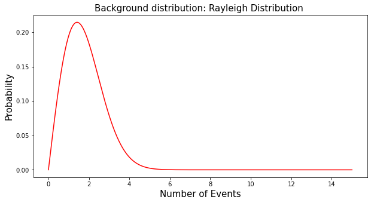

```python
plt.rcParams['figure.figsize'] = [10, 5]
fig, ax = plt.subplots(1, 1)
sigma = 2
def ray(x):
   return np.exp((-x**2)/(sigma**2))*(x/sigma**2)

x = np.linspace(0, 15, 1000)
ax.plot(x, ray(x), color='red', label="Continuous pdf()")
plt.title("Background distribution: Rayleigh Distribution ", size = 15)
plt.xlabel("Number of Events", size= 15)
plt.ylabel("Probability", size=15)
```

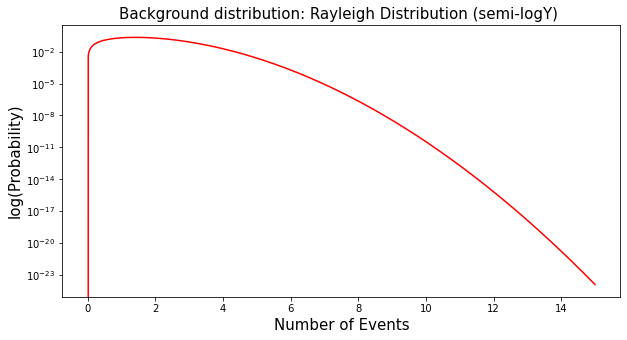

```python
#semi log
plt.rcParams['figure.figsize'] = [10, 5]
fig, ax = plt.subplots(1, 1)
plt.yscale('log')
ax.plot(x, ray(x), color='red', label="Continuous pdf()")
plt.title("Background distribution: Rayleigh Distribution (semi-logY) ", size = 15)
plt.xlabel("Number of Events", size= 15)
plt.ylabel("log(Probability)", size=15)
```

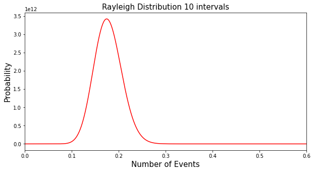

```python
ray_convolve = ray(x)
interval = 10

for i in range (interval-1):
    ray_convolve = np.convolve(ray(x), ray_convolve, mode = "full")

plt.rcParams['figure.figsize'] = [10, 5]
fig, ax = plt.subplots(1, 1)

x2 = np.linspace(0, 15/interval, 9991)
ax.plot(x2, ray_convolve, color='red', label="Continuous pdf()")
plt.title("Rayleigh Distribution " + str(interval) + " intervals", size = 15)
plt.xlabel("Number of Events", size= 15)
plt.ylabel("Probability", size=15)
plt.xlim(0, 0.6)
plt.show()
```

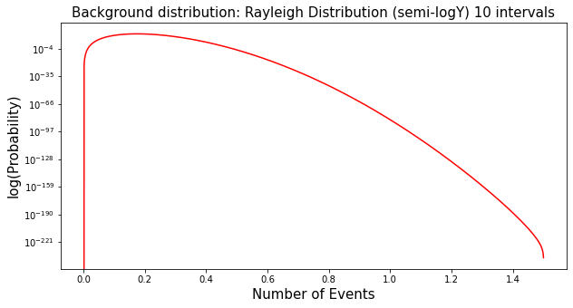

```python
#semi log
plt.rcParams['figure.figsize'] = [10, 5]
fig, ax = plt.subplots(1, 1)
plt.yscale('log')
x2 = np.linspace(0, 15/interval, 9991)
ax.plot(x2, ray_convolve, color='red', label="Continuous pdf()")
plt.title("Background distribution: Rayleigh Distribution (semi-logY) " + str(interval) + " intervals", size = 15)
plt.xlabel("Number of Events", size= 15)
plt.ylabel("log(Probability)", size=15)
```

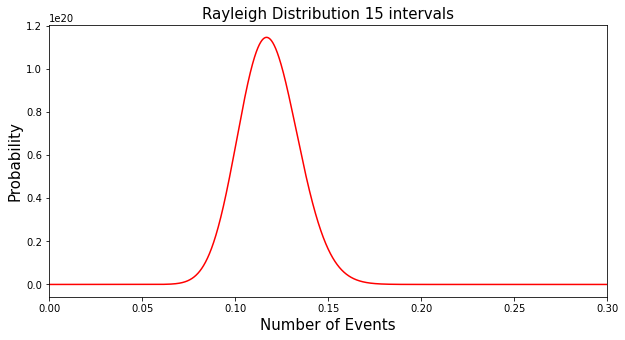

```python
ray_convolve = ray(x)
interval = 15

for i in range (interval-1):
    ray_convolve = np.convolve(ray(x), ray_convolve, mode = "full")

plt.rcParams['figure.figsize'] = [10, 5]
fig, ax = plt.subplots(1, 1)

x2 = np.linspace(0, 15/interval, 14986)
ax.plot(x2, ray_convolve, color='red', label="Continuous pdf()")
plt.title("Rayleigh Distribution " + str(interval) + " intervals", size = 15)
plt.xlabel("Number of Events", size= 15)
plt.ylabel("Probability", size=15)
plt.xlim(0, 0.3)
plt.show()
```

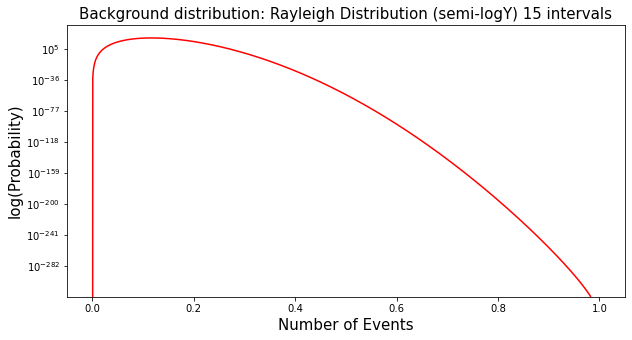

```python
#semi log
plt.rcParams['figure.figsize'] = [10, 5]
fig, ax = plt.subplots(1, 1)
plt.yscale('log')
x2 = np.linspace(0, 15/interval, 14986)
ax.plot(x2, ray_convolve, color='red', label="Continuous pdf()")
plt.title("Background distribution: Rayleigh Distribution (semi-logY) " + str(interval) + " intervals", size = 15)
plt.xlabel("Number of Events", size= 15)
plt.ylabel("log(Probability)", size=15)
```

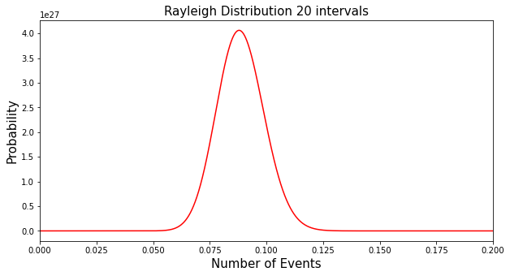

```python
ray_convolve = ray(x)
interval = 20

for i in range (interval-1):
    ray_convolve = np.convolve(ray(x), ray_convolve, mode = "full")

plt.rcParams['figure.figsize'] = [10, 5]
fig, ax = plt.subplots(1, 1)

x2 = np.linspace(0, 15/interval, 19981)
ax.plot(x2, ray_convolve, color='red', label="Continuous pdf()")
plt.title("Rayleigh Distribution " + str(interval) + " intervals", size = 15)
plt.xlabel("Number of Events", size= 15)
plt.ylabel("Probability", size=15)
plt.xlim(0, 0.2)
plt.show()
```

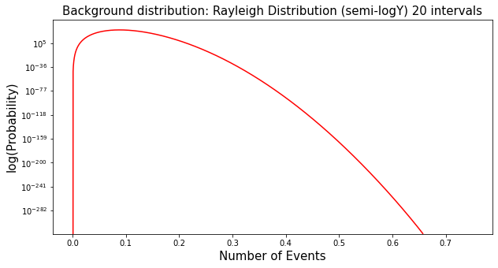

```python
#semi log
plt.rcParams['figure.figsize'] = [10, 5]
fig, ax = plt.subplots(1, 1)
plt.yscale('log')
x2 = np.linspace(0, 15/interval, 19981)
ax.plot(x2, ray_convolve, color='red', label="Continuous pdf()")
plt.title("Background distribution: Rayleigh Distribution (semi-logY) " + str(interval) + " intervals", size = 15)
plt.xlabel("Number of Events", size= 15)
plt.ylabel("log(Probability)", size=15)
```

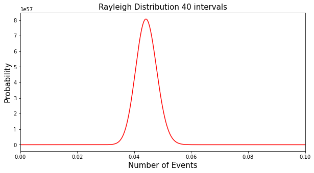

```python
ray_convolve = ray(x)
interval = 40

for i in range (interval-1):
    ray_convolve = np.convolve(ray(x), ray_convolve, mode = "full")

plt.rcParams['figure.figsize'] = [10, 5]
fig, ax = plt.subplots(1, 1)

x2 = np.linspace(0, 15/interval, 39961)
ax.plot(x2, ray_convolve, color='red', label="Continuous pdf()")
plt.title("Rayleigh Distribution " + str(interval) + " intervals", size = 15)
plt.xlabel("Number of Events", size= 15)
plt.ylabel("Probability", size=15)
plt.xlim(0, 0.1)
plt.show()
```

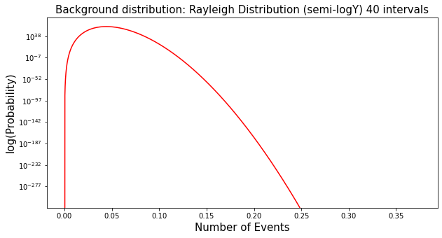

```python
#semi log
plt.rcParams['figure.figsize'] = [10, 5]
fig, ax = plt.subplots(1, 1)
plt.yscale('log')
x2 = np.linspace(0, 15/interval, 39961)
ax.plot(x2, ray_convolve, color='red', label="Continuous pdf()")
plt.title("Background distribution: Rayleigh Distribution (semi-logY) " + str(interval) + " intervals", size = 15)
plt.xlabel("Number of Events", size= 15)
plt.ylabel("log(Probability)", size=15)
```

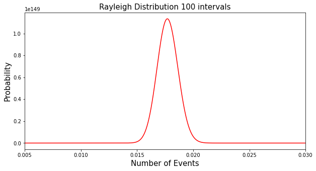

```python
ray_convolve = ray(x)
interval = 100

for i in range (interval-1):
    ray_convolve = np.convolve(ray(x), ray_convolve, mode = "full")

plt.rcParams['figure.figsize'] = [10, 5]
fig, ax = plt.subplots(1, 1)

x2 = np.linspace(0, 15/interval, 99901)
ax.plot(x2, ray_convolve, color='red', label="Continuous pdf()")
plt.title("Rayleigh Distribution " + str(interval) + " intervals", size = 15)
plt.xlabel("Number of Events", size= 15)
plt.ylabel("Probability", size=15)
plt.xlim(0.005, 0.03)
plt.show()
```

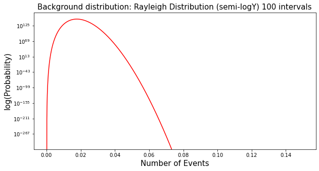

```python
#semi log
plt.rcParams['figure.figsize'] = [10, 5]
fig, ax = plt.subplots(1, 1)
plt.yscale('log')
x2 = np.linspace(0, 15/interval, 99901)
ax.plot(x2, ray_convolve, color='red', label="Continuous pdf()")
plt.title("Background distribution: Rayleigh Distribution (semi-logY) " + str(interval) + " intervals", size = 15)
plt.xlabel("Number of Events", size= 15)
plt.ylabel("log(Probability)", size=15)
```

## 3) Optical counterparts (a new optical source) of a gravity wave signal

### Version 1

A) From looking at all the other pixels in our image, we measure the width of the background Gaussian distribution X. We see a signal of strength Y. We will calculate the significance of our detection to see if we can claim a discovery (traditionally 5-sigma or more)?

```python
X = 1.3 # width of Gaussian distribution
Y = 7.7 # strength of signal

distribution = 1-stats.norm.cdf(Y, scale = X)
sigma = stats.norm.ppf(1-distribution)

print("Siginificants of our detection: " + str(sigma))
```

```
Siginificants of our detection: 5.923076917983112
```

AHOY! We have a discovery!! We have a $\sigma$ > 5!

### Version 2

We have an alert from LIGO, but no associated detection from SWIFT. This could be because it is a black hole-black hole merger, a black hole-neutron star merger (neither seem to emit X-rays or UV light), or it could because SWIFT was indisposed at the time (wrong side of the earth in its orbit). Whatever the cause, we know what region of the sky to look in, but not which pixel.

B) If we have to look for a signal in 10k pixels, what is the probability distribution of our background?

Statistical question: What is the probability that a signal of 7.7 is probuced with a background with 10k pixels? (We scale our original distribution by a 10k trial factor)

```python
distribution_10K = distribution*10000
sigma_10k = stats.norm.ppf(1-distribution_10K)

print("Siginificants of our detection at 10k pixels background: " + str(sigma_10k))
```

```
Siginificants of our detection at 10k pixels background: 4.161638000583354
```

C ) Well this time we get a $\sigma$ of 4.16 which is less than the 5$\sigma$ requirement for us here. Therefore our signal could have just been bacground signal. Not significant enought to claim a discovery.

## 3) Optical counterparts (a new optical source) of a gravity wave signal

A) Calculate the signal required for a 5-sigma detection in Version 1

```python
sigma_5 = scipy.stats.norm.sf(5)
signal = scipy.stats.norm.isf(sigma_5, scale = X)

print("Signal required for 5 sigmas is " + str(signal))
```

```
Signal required for 5 sigmas is 6.500000000000002
```

B) Calculate the signal required for a 5-sigma detection in Version 2

```python
sigma_5 = scipy.stats.norm.sf(5)/10000
signal2 = scipy.stats.norm.isf(sigma_5, scale = X)

print("Signal required for 5 sigmas with 10k pixels is " + str(signal2))
```

```
Signal required for 5 sigmas with 10k pixels is 8.515698896516934
```

C) Discuss how much brighter the signal must be for discoverey if you have a trials factor of 10k. Looking at your probability distributions, explain why the sensitivity penalty due to a trials factor is so low.

```python
factor = signal2/signal
print("If we have a trials factor of 10k, the signal must be " + str(factor) + " times brighter")
```

```
If we have a trials factor of 10k, the signal must be 1.3101075225410663 times brighter
```

The chances of us seeing a signal that is 1.3 times brigher is 1 in 10k, so the chances of us seeing a signal as bright or more than this is even lower.

D) If you changed the trials factor significantly (orders of magnitude), how large is the effect on your 5-sigma sensitivity threshold?

```python
trial_factor = 10e10
sigma_5 = scipy.stats.norm.sf(5)/trial_factor
signal3 = scipy.stats.norm.isf(sigma_5, scale = X)
factor = signal3/signal

print("Signal required for 5 sigmas with 10e10 pixels is " + str(signal3))
print("If we have a trials factor of 10e10, the signal must be " + str(factor) + " times brighter")
```

```
Signal required for 5 sigmas with 10e10 pixels is 11.22907652443293
If we have a trials factor of 10e10, the signal must be 1.7275502345281426 times brighter
```